# Lab 3 - LD

Becca DeCamp

6/15/2018

Basic plan:

- Intro: Explain intergenic LD, talk about 4 SNPs that we’re going to focus on, talk about difference between D’ and R^2 tests when looking at LD.
- Have them read it in and do LD with SnpStats. Tell them that the table is confusing and not to worry about it.
- Have them make LDheatmap with the image function, just to get a sense of the basic pattern of their LDheatmap.
- Have them make LDheatmap with package (possibly from smaller snippet, although I don’t think it’s really that bad tbh.) Have them label just the SNPs from the article and Ensembl. This would be where we would look at the smaller block; looking specifically at the SNPs associated with obesity and if theyre in LD according to their analyses. Have them make it with both R^2 and D’, to see how they differ.
- Have them download image file as a png so they can use it as a figure for their report.
- Have them look at Ensembl, and look at the LD block there. Is the pattern similar? Different?
- Have them look at alleles that are in LD with it. Are there SNPs not from UCP1? Are there phenotypic consequences linked to any of the alleles in LD?

## Introduction to Linkage Disequilibrium (LD)

### Learning Objectives

- Learn about rs6536991, rs35243591, rs2270565, and rs12502572 and their roles in obesity.
- Learn how to use the package SNPStats to perform LD analysis in a population.
- Learn how to create an LD heatmap using both D’ and R^2 to evaluate LD between SNPs
- Learn how to use Ensembl to look at SNPs in LD with UCP1 that are in other genes

## Step 1: Getting To RStudio And Preparing Your Data

Log in to the SCC and bring up the RStudio window like we did in the last lab:

```bash
#login
ssh -Y username@scc1.bu.edu
```

```bash
#access your directory and load your R space
cd /project/anth333/yourfilename
module load gcc
module load R
rstudio
```

Now that we’re in R, we can prepare our data for analysis. The functions we will use today take an argument of a “SNPMatrix,” so we will convert our data in to a SNPMatrix now. I will use the population YRI again as an example.

```r
#First, we load the packages we will be using, which should already be installed in SCC:

library(snpStats)
library(VariantAnnotation)
```

```r
library(LDheatmap)
```

Next, we will load in our data. Not only will we load in our VCF file of all the SNPs in UCP1, we will load in the smaller slice that we took in Lab 1 as well. We will load the VCF files in to our R space first, then use another function to transform them in to SNPMatrices.

```r
#We'll start with the full UCP1 file. Copy this code with the name of your VCF file. The 'hg19' is telling the function to align our data with the hg19 genome that comes with the package VariantAnnotation:

vcfbig <- readVcf("YRI.vcf", "hg19")

#Next, convert it to a SNPMatirx. Remember to replace "YRI" with the acronym for your own population:

YRImatrix <- genotypeToSnpMatrix(vcfbig)
```

```
## non-single nucleotide variations are set to NA
```

```r
YRImatrix #repeating the file name will show you what it looks like
```

```
## $genotypes
## A SnpMatrix with  108 rows and  208 columns
## Row names:  NA18486 ... NA19257
## Col names:  rs577971821 ... rs144172393
##
## $map
## DataFrame with 208 rows and 4 columns
##       snp.names       allele.1           allele.2    ignore
##     <character> <DNAStringSet> <DNAStringSetList> <logical>
## 1   rs577971821              C                  T     FALSE
## 2   rs538981371              A                  G     FALSE
## 3   rs558086468              T                  C     FALSE
## 4   rs201346519              G                 GA      TRUE
## 5    rs79001246              C                  A     FALSE
## ...         ...            ...                ...       ...
## 204 rs150067245              G                  A     FALSE
## 205 rs555213120              G                  T     FALSE
## 206 rs200045723              C                  T     FALSE
## 207  rs73856656              G                  A     FALSE
## 208 rs144172393             CT                  C      TRUE
```

```r
#Repeat this process with your smaller slice of UCP1:

vcfsmall <- readVcf("YRIsmall.vcf", "hg19")

YRIsmallmatrix <- genotypeToSnpMatrix(vcfsmall)
```

```
## non-single nucleotide variations are set to NA
```

```r
YRIsmallmatrix
```

```
## $genotypes
## A SnpMatrix with  108 rows and  84 columns
## Row names:  NA18486 ... NA19257
## Col names:  rs527960564 ... rs575055039
##
## $map
## DataFrame with 84 rows and 4 columns
##       snp.names       allele.1           allele.2    ignore
##     <character> <DNAStringSet> <DNAStringSetList> <logical>
## 1   rs527960564              C                  T     FALSE
## 2    rs78724285              C                  T     FALSE
## 3     rs6536991              T                  C     FALSE
## 4   rs538400756              C                  T     FALSE
## 5   rs550015648              A                  G     FALSE
## ...         ...            ...                ...       ...
## 80  rs559250260              A                  T     FALSE
## 81   rs12502572              G                  A     FALSE
## 82  rs541682474              A                  G     FALSE
## 83  rs559962748              T                  G     FALSE
## 84  rs575055039              G                  T     FALSE
```

Now what you’ll notice is that the “SNPMatrix” files we made actually are actually two separate files under one file name, and only one of them is the actual SNPMatrix. In order to call only the SNPMatrix in our functions, we will use “$genotypes” after our SNPMatrix’s name. You will see this in our following analyses.

## Step 2: Using the “ld” Function

Next, we will be using a function from the SNPStats package to look at LD across the whole UCP1 gene. To do this, we will use the ‘ld’ function to create an LD matrix, which we will then graph to comprehend it better. First, we’ll use the ‘ld’ function like so:

```r
#For "Stats," use "R.squared" for now. We will explore D' later. Make sure to substitute "YRImatrix" for what you called your larger SNPMatrix

LD <- ld(YRImatrix$genotypes, depth = 200, stats = "R.squared")
LD
```

```
## 208 x 208 sparse Matrix of class "dgCMatrix"
```

```
##    [[ suppressing 208 column names 'rs577971821', 'rs538981371', 'rs558086468' ... ]]
```

```
##
## rs577971821 . NA NA NA NA NA           NA NA NA           NA NA
## rs538981371 .  . NA NA NA NA           NA NA NA           NA NA
## rs558086468 .  .  . NA NA NA           NA NA NA           NA NA
## rs201346519 .  .  .  . NA NA           NA NA NA           NA NA
## rs79001246  .  .  .  .  . NA 0.0001557806 NA NA 0.0154416990 NA
## rs142885075 .  .  .  .  .  .           NA NA NA           NA NA
## rs146114327 .  .  .  .  .  . .            NA NA 0.0001102171 NA
## rs142145526 .  .  .  .  .  . .             . NA           NA NA
## rs543991038 .  .  .  .  .  . .             .  .           NA NA
## rs562565974 .  .  .  .  .  . .             .  . .            NA
## rs117949489 .  .  .  .  .  . .             .  . .             .
## rs551356095 .  .  .  .  .  . .             .  . .             .
## rs145918476 .  .  .  .  .  . .             .  . .             .
## rs527960564 .  .  .  .  .  . .             .  . .             .
## rs78724285  .  .  .  .  .  . .             .  . .             .
## rs6536991   .  .  .  .  .  . .             .  . .             .
## rs538400756 .  .  .  .  .  . .             .  . .             .
## rs550015648 .  .  .  .  .  . .             .  . .             .
## rs571666957 .  .  .  .  .  . .             .  . .             .
## rs726989    .  .  .  .  .  . .             .  . .             .
## rs145573095 .  .  .  .  .  . .             .  . .             .
## rs5862487   .  .  .  .  .  . .             .  . .             .
## rs182883393 .  .  .  .  .  . .             .  . .             .
## rs534102407 .  .  .  .  .  . .             .  . .             .
## rs187220083 .  .  .  .  .  . .             .  . .             .
## rs192528115 .  .  .  .  .  . .             .  . .             .
## rs544349406 .  .  .  .  .  . .             .  . .             .
## rs148892327 .  .  .  .  .  . .             .  . .             .
## rs530434699 .  .  .  .  .  . .             .  . .             .
## rs2043124   .  .  .  .  .  . .             .  . .             .
## rs544637184 .  .  .  .  .  . .             .  . .             .
## rs537726509 .  .  .  .  .  . .             .  . .             .
## rs117858590 .  .  .  .  .  . .             .  . .             .
## rs35243591  .  .  .  .  .  . .             .  . .             .
## rs568352524 .  .  .  .  .  . .             .  . .             .
## rs549281392 .  .  .  .  .  . .             .  . .             .
## rs561587316 .  .  .  .  .  . .             .  . .             .
## rs2043123   .  .  .  .  .  . .             .  . .             .
## rs550345422 .  .  .  .  .  . .             .  . .             .
```

[output cut: 3498 more lines]

```
## rs566741523           NA NA NA NA NA NA NA NA NA NA NA           NA NA
## rs183997397           NA NA NA NA NA NA NA NA NA NA NA           NA NA
## rs2071415   .            NA NA NA NA NA NA NA NA NA NA 0.1020104244 NA
## rs567743945 .             . NA NA NA NA NA NA NA NA NA           NA NA
## rs188981515 .             .  . NA NA NA NA NA NA NA NA           NA NA
## rs556504882 .             .  .  . NA NA NA NA NA NA NA           NA NA
## rs569203186 .             .  .  .  . NA NA NA NA NA NA           NA NA
## rs539766026 .             .  .  .  .  . NA NA NA NA NA           NA NA
## rs558049733 .             .  .  .  .  .  . NA NA NA NA           NA NA
## rs573078239 .             .  .  .  .  .  .  . NA NA NA           NA NA
## rs150067245 .             .  .  .  .  .  .  .  . NA NA           NA NA
## rs555213120 .             .  .  .  .  .  .  .  .  . NA           NA NA
## rs200045723 .             .  .  .  .  .  .  .  .  .  .           NA NA
## rs73856656  .             .  .  .  .  .  .  .  .  .  . .            NA
## rs144172393 .             .  .  .  .  .  .  .  .  .  . .             .
```

This will give you a matrix of LD values. This is probably confusing to look at. An LD analysis output like this can be hard to interpret without a visual aid, so we will build one. The output of this function (our “LD” object) is what we’ll use as an input to make sense of what this table means.

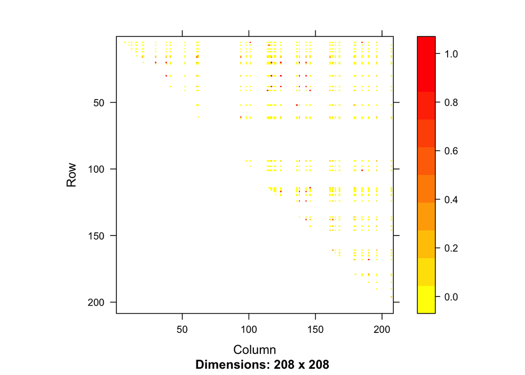

```r
#sets color scale for the graph
cols = colorRampPalette(c("yellow", "red"))(10)
#building the image
image(LD, lwd = 0, cuts= 9, col.regions=cols, colorkey=TRUE)
```

You can see that much of this gene shows very low LD, but there are several blips where high LD is observed. What could this mean?

## Part 3: Measuring LD in Our SNPs Of Interest

```r
positions <- c(141481462, 141481520, 141481581, 141481612, 141481686, 141481733, 141481761, 141481841, 141481902, 141481946, 141481962, 141482038, 141482137, 141482180, 141482216, 141482228, 141482306, 141482327, 141482336, 141482472, 141482484, 141482511, 141482527, 141482664, 141482681, 141482691, 141482768, 141482785, 141482846, 141482867, 141482879, 141482897, 141483020, 141483130, 141483271, 141483330, 141483338, 141483389, 141483471, 141483476, 141483481, 141483503, 141483539, 141483540, 141483551, 141483675, 141483685, 141483735, 141483781, 141483814, 141483893, 141483997, 141484041, 141484046, 141484075, 141484144, 141484182, 141484200, 141484292, 141484309, 141484351, 141484363, 141484369, 141484372, 141484416, 141484492, 141484533, 141484536, 141484540, 141484577, 141484632, 141484684, 141484734, 141484802, 141484876, 141484908, 141485004, 141485065, 141485088, 141485098, 141485134, 141485172, 141485177, 141485260)
```

Now, here is the code to create the LD heatmap showing the R squared statistic. The only thing you have to change in this code is to replace the “YRIsmallmatrix” value with the name that you gave your smaller SNPMatrix. Leave the “$genotypes” part of the command though, just like in the ld function. Run the rest of the code as normal.

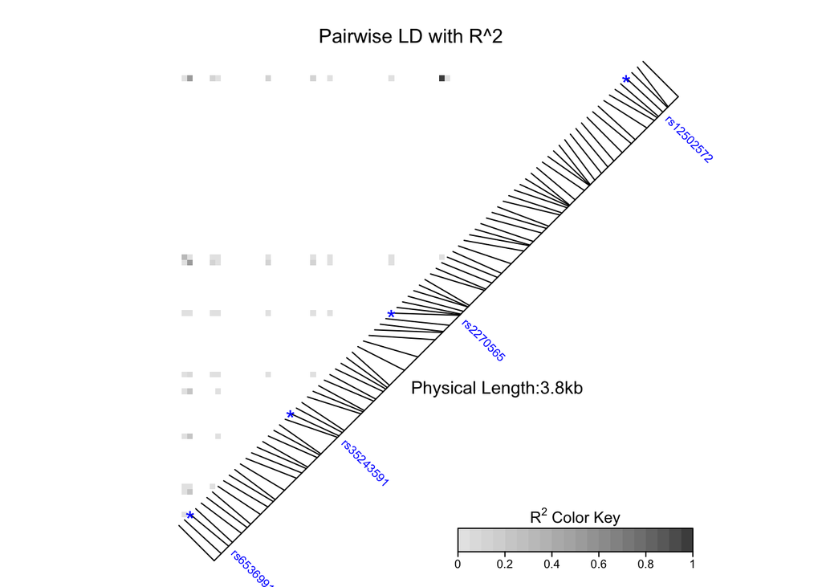

```r
smallheatmapr <- LDheatmap(YRIsmallmatrix$genotype, genetic.distances=positions, distances="physical",
LDmeasure="r", title="Pairwise LD with R^2", add.map=TRUE, add.key=TRUE,
geneMapLocation=0.15,
SNP.name=c("rs6536991", "rs35243591", "rs2270565", "rs12502572"), color=NULL, newpage=TRUE,
name="ldheatmap")
```

```r
smallheatmapr
```

```
## $LDmatrix
##             rs527960564 rs78724285  rs6536991 rs538400756 rs550015648
## rs527960564          NA         NA         NA          NA          NA
## rs78724285           NA         NA 0.01964286          NA          NA
## rs6536991            NA         NA         NA          NA          NA
## rs538400756          NA         NA         NA          NA          NA
## rs550015648          NA         NA         NA          NA          NA
## rs571666957          NA         NA         NA          NA          NA
## rs726989             NA         NA         NA          NA          NA
## rs145573095          NA         NA         NA          NA          NA
## rs5862487            NA         NA         NA          NA          NA
## rs182883393          NA         NA         NA          NA          NA
## rs534102407          NA         NA         NA          NA          NA
## rs187220083          NA         NA         NA          NA          NA
## rs192528115          NA         NA         NA          NA          NA
## rs544349406          NA         NA         NA          NA          NA
## rs148892327          NA         NA         NA          NA          NA
## rs530434699          NA         NA         NA          NA          NA
## rs2043124            NA         NA         NA          NA          NA
## rs544637184          NA         NA         NA          NA          NA
## rs537726509          NA         NA         NA          NA          NA
## rs117858590          NA         NA         NA          NA          NA
## rs35243591           NA         NA         NA          NA          NA
## rs568352524          NA         NA         NA          NA          NA
## rs549281392          NA         NA         NA          NA          NA
## rs561587316          NA         NA         NA          NA          NA
## rs2043123            NA         NA         NA          NA          NA
## rs550345422          NA         NA         NA          NA          NA
## rs571684831          NA         NA         NA          NA          NA
## rs56220366           NA         NA         NA          NA          NA
## rs547884746          NA         NA         NA          NA          NA
## rs183105785          NA         NA         NA          NA          NA
## rs143604530          NA         NA         NA          NA          NA
## rs567550714          NA         NA         NA          NA          NA
## rs76122323           NA         NA         NA          NA          NA
## rs556306518          NA         NA         NA          NA          NA
## rs147980705          NA         NA         NA          NA          NA
## rs553417300          NA         NA         NA          NA          NA
## rs142396002          NA         NA         NA          NA          NA
## rs140138182          NA         NA         NA          NA          NA
```

[output cut: 1425 more lines]

```
## [57] 141484182 141484200 141484292 141484309 141484351 141484363 141484369
## [64] 141484372 141484416 141484492 141484533 141484536 141484540 141484577
## [71] 141484632 141484684 141484734 141484802 141484876 141484908 141485004
## [78] 141485065 141485088 141485098 141485134 141485172 141485177 141485260
##
## $distances
## [1] "physical"
##
## $color
##  [1] "#4D4D4D" "#5D5D5D" "#6B6B6B" "#767676" "#818181" "#8A8A8A" "#939393"
##  [8] "#9C9C9C" "#A3A3A3" "#ABABAB" "#B2B2B2" "#B8B8B8" "#BFBFBF" "#C5C5C5"
## [15] "#CBCBCB" "#D0D0D0" "#D6D6D6" "#DBDBDB" "#E0E0E0" "#E6E6E6"
##
## attr(,"class")
## [1] "LDheatmap"
```

Next, we will make the graph displaying the D prime statistic. Again, all you have to replace in this code is the “YRIsmallmatrix” with the name you gave your smaller matrix.

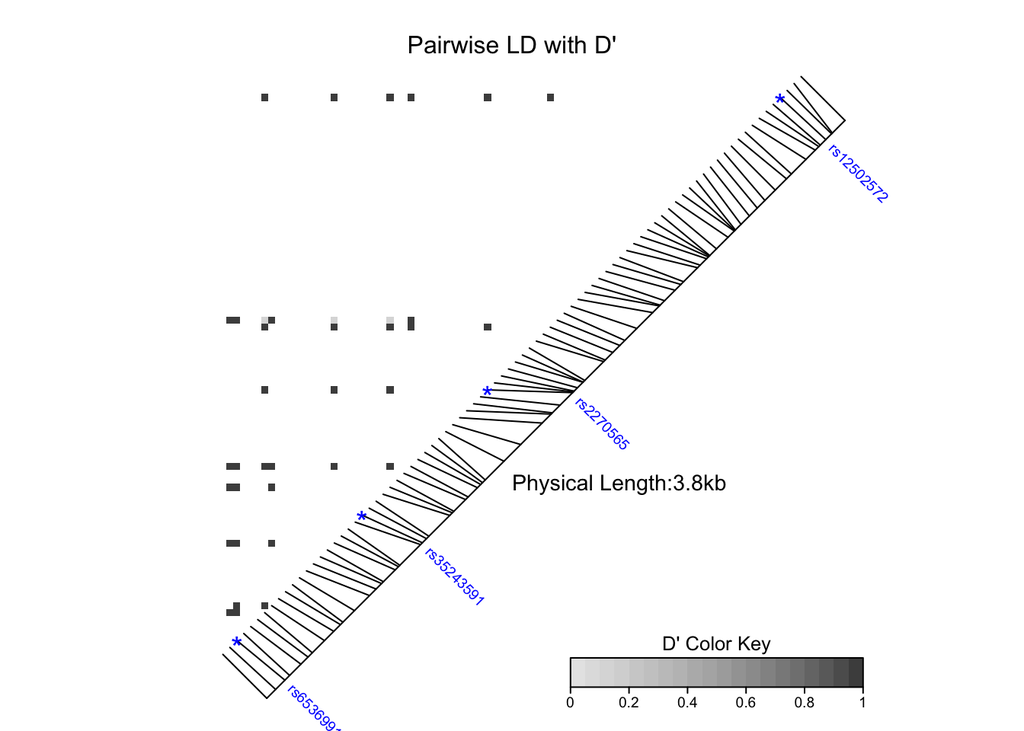

```r
smallheatmapD <- LDheatmap(YRIsmallmatrix$genotype, genetic.distances=positions, distances="physical",
LDmeasure="D", title="Pairwise LD with D'", add.map=TRUE, add.key=TRUE,
geneMapLocation=0.15,
SNP.name=c("rs6536991", "rs35243591", "rs2270565", "rs12502572"), color=NULL, newpage=TRUE,
name="ldheatmap")
```

```r
smallheatmapD
```

```
## $LDmatrix
##             rs527960564 rs78724285 rs6536991 rs538400756 rs550015648
## rs527960564          NA         NA        NA          NA          NA
## rs78724285           NA         NA         1          NA          NA
## rs6536991            NA         NA        NA          NA          NA
## rs538400756          NA         NA        NA          NA          NA
## rs550015648          NA         NA        NA          NA          NA
## rs571666957          NA         NA        NA          NA          NA
## rs726989             NA         NA        NA          NA          NA
## rs145573095          NA         NA        NA          NA          NA
## rs5862487            NA         NA        NA          NA          NA
## rs182883393          NA         NA        NA          NA          NA
## rs534102407          NA         NA        NA          NA          NA
## rs187220083          NA         NA        NA          NA          NA
## rs192528115          NA         NA        NA          NA          NA
## rs544349406          NA         NA        NA          NA          NA
## rs148892327          NA         NA        NA          NA          NA
## rs530434699          NA         NA        NA          NA          NA
## rs2043124            NA         NA        NA          NA          NA
## rs544637184          NA         NA        NA          NA          NA
## rs537726509          NA         NA        NA          NA          NA
## rs117858590          NA         NA        NA          NA          NA
## rs35243591           NA         NA        NA          NA          NA
## rs568352524          NA         NA        NA          NA          NA
## rs549281392          NA         NA        NA          NA          NA
## rs561587316          NA         NA        NA          NA          NA
## rs2043123            NA         NA        NA          NA          NA
## rs550345422          NA         NA        NA          NA          NA
## rs571684831          NA         NA        NA          NA          NA
## rs56220366           NA         NA        NA          NA          NA
## rs547884746          NA         NA        NA          NA          NA
## rs183105785          NA         NA        NA          NA          NA
## rs143604530          NA         NA        NA          NA          NA
## rs567550714          NA         NA        NA          NA          NA
## rs76122323           NA         NA        NA          NA          NA
## rs556306518          NA         NA        NA          NA          NA
## rs147980705          NA         NA        NA          NA          NA
## rs553417300          NA         NA        NA          NA          NA
## rs142396002          NA         NA        NA          NA          NA
## rs140138182          NA         NA        NA          NA          NA
```

[output cut: 1425 more lines]

```
## [57] 141484182 141484200 141484292 141484309 141484351 141484363 141484369
## [64] 141484372 141484416 141484492 141484533 141484536 141484540 141484577
## [71] 141484632 141484684 141484734 141484802 141484876 141484908 141485004
## [78] 141485065 141485088 141485098 141485134 141485172 141485177 141485260
##
## $distances
## [1] "physical"
##
## $color
##  [1] "#4D4D4D" "#5D5D5D" "#6B6B6B" "#767676" "#818181" "#8A8A8A" "#939393"
##  [8] "#9C9C9C" "#A3A3A3" "#ABABAB" "#B2B2B2" "#B8B8B8" "#BFBFBF" "#C5C5C5"
## [15] "#CBCBCB" "#D0D0D0" "#D6D6D6" "#DBDBDB" "#E0E0E0" "#E6E6E6"
##
## attr(,"class")
## [1] "LDheatmap"
```

Now you’ve got two graphs that you can use for your report! You can see specifically whether or not the SNPs of interest (the labelled SNPs) by finding where on the graph their paths intersect. Or, for the purpose of reporting your results, we can look at something called an LD matrix that was generated by the LD heatmap function. This is a matrix where the row and columnn names are SNP ID numbers, and the cell at the intersection of a row and a column will tell you the LD statistic for those two particular SNPs. For our purposes, you do not need to look at the whole chart, you just need to find the intersections of our four SNPs of interest to see if any of them are in LD, and what that LD value is for each respective statistical test.  
To view your LD matrices, run this code: